# lab5

Neha Maddali

11/16/2021

```r
library(ggplot2)
library(dplyr)
library(tidyverse)
library(stringr)
library(lubridate)
library(scales)
library(readxl)

#import csv files
acc <- read.csv("https://raw.githubusercontent.com/xdaiISU/ds202materials/master/hwlabs/fars2017/accident.csv", stringsAsFactors = FALSE)
person <- read.csv("https://raw.githubusercontent.com/xdaiISU/ds202materials/master/hwlabs/fars2017/person.csv", stringsAsFactors = FALSE)
```

## Question 1

Create a data frame containing the persons who are fatally hurt in the accidents (see FARS manual and look up variable INJ_SEV)

```r
fatal <- person %>% filter(INJ_SEV == 4)
```

## Question 2

Create a data frame containing the most dangerous vehicle make in each state. The number of persons fatally hit in the vehicle make is used to assess the (non-)safety of a make. Make sure to handle the missing values appropriately. (look up variable MAKE)

```r
danger <- fatal %>% group_by(STATE, MAKE) %>%
  summarise(numfatal = n())
danger <- danger %>% na.omit() %>%
  group_by(STATE) %>%
  filter(numfatal == max(numfatal))
```

## Question 3

Create a map, and label each state with the most dangerous vehicle. Discuss the definition of the most dangerous vehicle, and what you find from the map. (Hint: Read the description for the STATE and COUNTY columns in the FARS manual. The state & county codes are Geographic Locator Codes (GLCs) from the General Services Administration’s (GSA) publication. Use readxl::read_xlsx to read in the GLCs.)

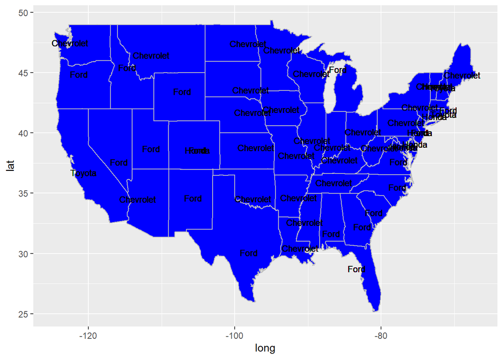

```r
GLCs <- readxl::read_xlsx("FRPP_GLC_-_United_StatesNov42021.xlsx")
states <- map_data('state')
GLCs$'State Name' <- tolower(GLCs$'State Name')
GLCs$'State Code' <- as.numeric(GLCs$'State Code')
labels <- states %>%
  group_by(region) %>%
  summarise(long= mean(long, na.rm = TRUE), lat= mean(lat, na.rm = TRUE))
labels <- left_join(labels, GLCs, by = c("region" = "State Name"))
labels <- left_join(labels, danger, by = c("State Code" = "STATE"))
labels$MAKE <- factor(labels$MAKE, levels = c(12, 20, 49, 37),
                      labels = c("Ford", "Chevrolet", "Toyota", "Honda"))
states %>% ggplot() +
  geom_polygon( aes(x=long, y=lat, group=group),
                color="grey", fill="blue" ) + geom_text(data=labels, aes(label =
                                                                            MAKE, x=long, y=lat), color="black", size=3)
```

## Question 4

Join the accident and person table (work out which variable(s) to use)

```r
joinedTables <- inner_join(person, acc, by="ST_CASE")
```

## Question 5

Tally the number of accidents by day of the week (DAY_WEEK), hour of the day (HOUR) and gender (SEX). Visualize the results and explain what you find.

```r
tallied <- joinedTables %>%
  filter(SEX == 1 || SEX == 2) %>%
  group_by(ST_CASE) %>%
  summarise(avgSex = mean(SEX))
tallied$sexStr <- ifelse(tallied$avgSex == 1, 'Men', ifelse(tallied$avgSex == 2, 'Women', 'Both'))
accident <- tallied %>%
  select(ST_CASE, sexStr) %>%
  inner_join(acc, by='ST_CASE')
grouped <- accident %>%
  filter(HOUR <= 24) %>%
  filter(DAY_WEEK != 9) %>%
  group_by(sexStr, HOUR, DAY_WEEK) %>%
  summarise(numAccidents = n()) %>%
  arrange(desc(numAccidents))
```

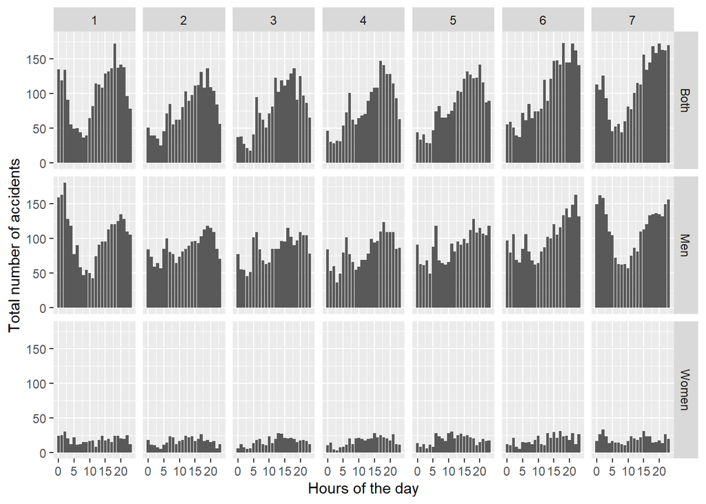

```r
ggplot(grouped,aes(x=HOUR, y=numAccidents)) +
  geom_bar(stat='identity') +
  facet_grid(sexStr~DAY_WEEK) +
  xlab("Hours of the day") +
  ylab("Total number of accidents")
```

**The graph I’ve created has three rows of graphs. The rows are data for both men and women, men, and then women. The columns of graphs are ordered by days of the week. The x-axis is the hour of day and the y-axis is the total number of accidents. Men, evidently, get into more accidents than women. It seems like the most accidents occur in the weekends. But in general, most accidents occur at night.**

## Question 6

Now plot a choropleth map of the number of deaths on a county level. Also explain what you find.

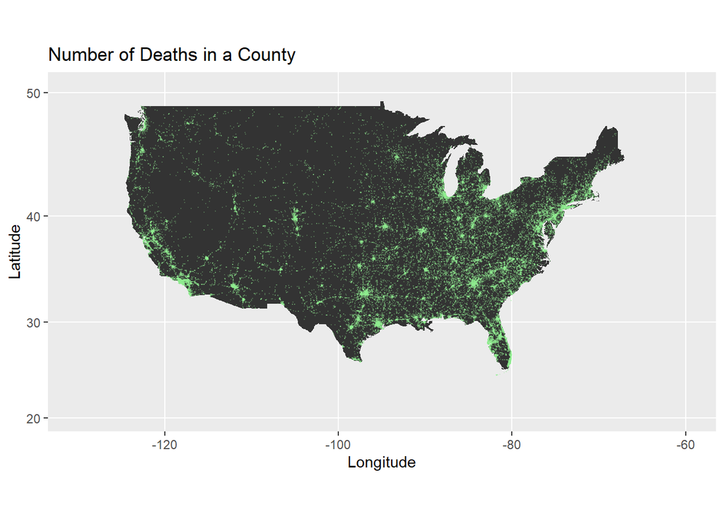

```r
deaths <- accident %>%
  inner_join(fatal %>%
               select(INJ_SEV, ST_CASE),
             by=c("ST_CASE")) %>%
  summarize(INJ_SEV, ST_CASE, LATITUDE, LONGITUD, STATE)

ggplot(states, aes(x=long, y=lat)) +
  geom_polygon(aes(group=group)) + geom_point(aes(x=LONGITUD, y=LATITUDE),
                                              data=deaths %>% filter(INJ_SEV == 4),
                                              color = 'lightgreen',alpha=0.2,size=0.02)+
  xlim(-130,-60)+ylim(20,50)+coord_map()+labs(x="Longitude",y="Latitude",title="Number of Deaths in a County")
```

**The most deaths, shown by the green dots on the map, seem to occur on the east cost.**

## Question 7 (optional)

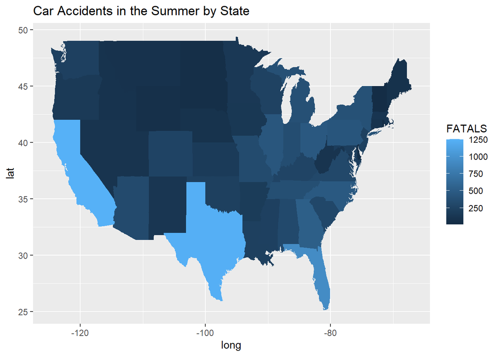

```r
df <- readxl::read_xlsx("FRPP_GLC_-_United_StatesNov42021.xlsx")
states <- map_data('state')
counties <- map_data('county')

var <- c("STATE", "COUNTY", "FATALS")
fatals <- acc[var]
df$'State Code' <- as.numeric(df$`State Code`)
df$'City Code' <- as.numeric(df$`City Code`)
df$'County Code' <- as.numeric(df$`County Code`)
fatals <- fatals %>% group_by(STATE, COUNTY) %>%
  summarize(FATALS = sum(FATALS))
Winter <- acc %>%
  filter(MONTH < 5 | MONTH > 10)
Summer <- acc %>%
  filter(MONTH > 5 & MONTH < 10)
var3 <- c("State Name", "State Code")
df2 <- df[var3]
df2 <- unique(df2)
winterFatal <- Winter %>%
  group_by(STATE) %>%
  summarize(FATALS = sum(FATALS))
summerFatal <- Summer %>%
  group_by(STATE) %>%
  summarize(FATALS = sum(FATALS))
summerFatal <- summerFatal %>% left_join(df2, by=c('STATE' = 'State Code'))
summerFatal$`State Name` <- tolower(summerFatal$`State Name`)
summerFatal <- summerFatal %>% right_join(states, by=c('State Name' = 'region'))
var2 <- c("STATE", "FATALS", "long", "lat", "group")
summerFatal <- summerFatal[var2]
ggplot(summerFatal, aes(x=long, y=lat, fill = FATALS)) +
  geom_polygon(aes(group = group)) +
  labs(title = "Car Accidents in the Summer by State")
```

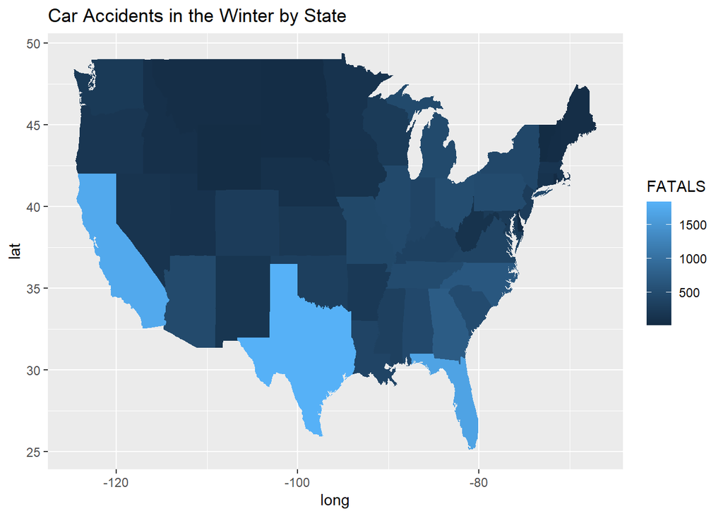

```r
winterFatal <- winterFatal %>% left_join(df2, by=c('STATE' = 'State Code'))
winterFatal$`State Name` <- tolower(winterFatal$`State Name`)
winterFatal <- winterFatal %>% right_join(states, by=c('State Name' = 'region'))
winterFatal <- winterFatal[var2]
ggplot(winterFatal, aes(x=long, y=lat, fill = FATALS)) +
  geom_polygon(aes(group = group)) +
  labs(title = "Car Accidents in the Winter by State")
```